# Projeto de Análise de Dados e Previsão de Preços das casas em King County, USA

#### Primeiramente, esse projeto tem como objetivo fazer uma análise de dados mais cautelosa e profissional utilizando métodos estatistícos para a análise de caracteristícas que mais impactam os valores das casas de King County, além da criação de um modelo que possa prever os valores das casas com base nas caracteristícas dadas. Vale ressaltar, que esse projeto usa como base um Dataset disponibilizado pela IBM durante o Projeto Final do curso 'Data Analysis with Python', na plataforma Coursera.

# Sobre o Dataset

Este dataset contém preços de venda das casas de King County, que inclui Seattle. Incluindo, as casas vendidas entre maio de 2014 e maio de 2015. Foi retirado aqui. Este dataset foi modificado pelos professores do curso.

| Variable | Description |
| --- | --- |
| id | A notation for a house |
| date | Date house was sold |
| price | Price is prediction target |
| bedrooms | Number of bedrooms |
| bathrooms | Number of bathrooms |
| sqft_living | Square footage of the home |
| sqft_lot | Square footage of the lot |
| floors | Total floors (levels) in house |
| waterfront | House which has a view to a waterfront |
| view | Has been viewed |
| condition | How good the condition is overall |
| grade | overall grade given to the housing unit, based on King County grading system |
| sqft_above | Square footage of house apart from basement |
| sqft_basement | Square footage of the basement |
| yr_built | Built Year |
| yr_renovated | Year when house was renovated |
| zipcode | Zip code |
| lat | Latitude coordinate |
| long | Longitude coordinate |
| sqft_living15 | Living room area in 2015(implies-- some renovations) This might or might not have affected the lotsize area |
| sqft_lot15 | LotSize area in 2015(implies-- some renovations) |

### Importando as bibliotecas utilizadas...

```python
import pandas as pd
import matplotlib.pyplot as plt
import matplotlib.ticker as ticker
import numpy as np
import seaborn as sns
from sklearn.pipeline import Pipeline
from sklearn.preprocessing import StandardScaler,PolynomialFeatures
from sklearn.linear_model import LinearRegression, Ridge
from sklearn.model_selection import train_test_split, cross_val_score, GridSearchCV
from sklearn.metrics import r2_score
from scipy import stats

%matplotlib inline
```

```python
## Função modelo para a criação dos gráficos
def DistributionPlot(RedFunction, BlueFunction, RedName, BlueName, Title):
    width = 16
    height = 9
    plt.figure(figsize=(width, height))

    ax1 = sns.kdeplot(RedFunction, color="r", label=RedName)
    ax2 = sns.kdeplot(BlueFunction, color="b", label=BlueName, ax=ax1)
    ax1.xaxis.set_major_formatter(ticker.FuncFormatter(lambda x, pos: '{:,.2f}'.format(x)))
    ax1.set(xlim=(min(df['price']),max(df['price'])))
    plt.legend()
    plt.title(Title)
    plt.xlabel('Price (in dollars)')
    plt.ylabel('Proportion of Houses')
    plt.show()
    plt.close()
```

## Importando e entendendo o dataset:

```python
df = pd.read_csv("housing.csv")
display(df.head())
```

|  | Unnamed: 0 | id | date | price | bedrooms | bathrooms | sqft_living | sqft_lot | floors | waterfront | ... | grade | sqft_above | sqft_basement | yr_built | yr_renovated | zipcode | lat | long | sqft_living15 | sqft_lot15 |
| --- | --- | --- | --- | --- | --- | --- | --- | --- | --- | --- | --- | --- | --- | --- | --- | --- | --- | --- | --- | --- | --- |
| 0 | 0 | 7129300520 | 20141013T000000 | 221900.0 | 3.0 | 1.00 | 1180 | 5650 | 1.0 | 0 | ... | 7 | 1180 | 0 | 1955 | 0 | 98178 | 47.5112 | -122.257 | 1340 | 5650 |
| 1 | 1 | 6414100192 | 20141209T000000 | 538000.0 | 3.0 | 2.25 | 2570 | 7242 | 2.0 | 0 | ... | 7 | 2170 | 400 | 1951 | 1991 | 98125 | 47.7210 | -122.319 | 1690 | 7639 |
| 2 | 2 | 5631500400 | 20150225T000000 | 180000.0 | 2.0 | 1.00 | 770 | 10000 | 1.0 | 0 | ... | 6 | 770 | 0 | 1933 | 0 | 98028 | 47.7379 | -122.233 | 2720 | 8062 |
| 3 | 3 | 2487200875 | 20141209T000000 | 604000.0 | 4.0 | 3.00 | 1960 | 5000 | 1.0 | 0 | ... | 7 | 1050 | 910 | 1965 | 0 | 98136 | 47.5208 | -122.393 | 1360 | 5000 |
| 4 | 4 | 1954400510 | 20150218T000000 | 510000.0 | 3.0 | 2.00 | 1680 | 8080 | 1.0 | 0 | ... | 8 | 1680 | 0 | 1987 | 0 | 98074 | 47.6168 | -122.045 | 1800 | 7503 |

5 rows × 22 columns

```python
display(df.info())
# É possível perceber que o dataset possui seus dtypes condizentes, apenas a data que distoa, além disso é perceptível que há valores nulos, logo precisaremos tratar a base de dados.
```

```
<class 'pandas.core.frame.DataFrame'>
RangeIndex: 21613 entries, 0 to 21612
Data columns (total 22 columns):
 #   Column         Non-Null Count  Dtype
---  ------         --------------  -----
 0   Unnamed: 0     21613 non-null  int64
 1   id             21613 non-null  int64
 2   date           21613 non-null  object
 3   price          21613 non-null  float64
 4   bedrooms       21600 non-null  float64
 5   bathrooms      21603 non-null  float64
 6   sqft_living    21613 non-null  int64
 7   sqft_lot       21613 non-null  int64
 8   floors         21613 non-null  float64
 9   waterfront     21613 non-null  int64
 10  view           21613 non-null  int64
 11  condition      21613 non-null  int64
 12  grade          21613 non-null  int64
 13  sqft_above     21613 non-null  int64
 14  sqft_basement  21613 non-null  int64
 15  yr_built       21613 non-null  int64
 16  yr_renovated   21613 non-null  int64
 17  zipcode        21613 non-null  int64
 18  lat            21613 non-null  float64
 19  long           21613 non-null  float64
 20  sqft_living15  21613 non-null  int64
 21  sqft_lot15     21613 non-null  int64
dtypes: float64(6), int64(15), object(1)
memory usage: 3.6+ MB
```

```
None
```

```python
display(df.describe())
# Algumas informações estatistícas relevantes que colaboram para a análise posterior.
```

|  | Unnamed: 0 | id | price | bedrooms | bathrooms | sqft_living | sqft_lot | floors | waterfront | view | ... | grade | sqft_above | sqft_basement | yr_built | yr_renovated | zipcode | lat | long | sqft_living15 | sqft_lot15 |
| --- | --- | --- | --- | --- | --- | --- | --- | --- | --- | --- | --- | --- | --- | --- | --- | --- | --- | --- | --- | --- | --- |
| count | 21613.00000 | 2.161300e+04 | 2.161300e+04 | 21600.000000 | 21603.000000 | 21613.000000 | 2.161300e+04 | 21613.000000 | 21613.000000 | 21613.000000 | ... | 21613.000000 | 21613.000000 | 21613.000000 | 21613.000000 | 21613.000000 | 21613.000000 | 21613.000000 | 21613.000000 | 21613.000000 | 21613.000000 |
| mean | 10806.00000 | 4.580302e+09 | 5.400881e+05 | 3.372870 | 2.115736 | 2079.899736 | 1.510697e+04 | 1.494309 | 0.007542 | 0.234303 | ... | 7.656873 | 1788.390691 | 291.509045 | 1971.005136 | 84.402258 | 98077.939805 | 47.560053 | -122.213896 | 1986.552492 | 12768.455652 |
| std | 6239.28002 | 2.876566e+09 | 3.671272e+05 | 0.926657 | 0.768996 | 918.440897 | 4.142051e+04 | 0.539989 | 0.086517 | 0.766318 | ... | 1.175459 | 828.090978 | 442.575043 | 29.373411 | 401.679240 | 53.505026 | 0.138564 | 0.140828 | 685.391304 | 27304.179631 |
| min | 0.00000 | 1.000102e+06 | 7.500000e+04 | 1.000000 | 0.500000 | 290.000000 | 5.200000e+02 | 1.000000 | 0.000000 | 0.000000 | ... | 1.000000 | 290.000000 | 0.000000 | 1900.000000 | 0.000000 | 98001.000000 | 47.155900 | -122.519000 | 399.000000 | 651.000000 |
| 25% | 5403.00000 | 2.123049e+09 | 3.219500e+05 | 3.000000 | 1.750000 | 1427.000000 | 5.040000e+03 | 1.000000 | 0.000000 | 0.000000 | ... | 7.000000 | 1190.000000 | 0.000000 | 1951.000000 | 0.000000 | 98033.000000 | 47.471000 | -122.328000 | 1490.000000 | 5100.000000 |
| 50% | 10806.00000 | 3.904930e+09 | 4.500000e+05 | 3.000000 | 2.250000 | 1910.000000 | 7.618000e+03 | 1.500000 | 0.000000 | 0.000000 | ... | 7.000000 | 1560.000000 | 0.000000 | 1975.000000 | 0.000000 | 98065.000000 | 47.571800 | -122.230000 | 1840.000000 | 7620.000000 |
| 75% | 16209.00000 | 7.308900e+09 | 6.450000e+05 | 4.000000 | 2.500000 | 2550.000000 | 1.068800e+04 | 2.000000 | 0.000000 | 0.000000 | ... | 8.000000 | 2210.000000 | 560.000000 | 1997.000000 | 0.000000 | 98118.000000 | 47.678000 | -122.125000 | 2360.000000 | 10083.000000 |
| max | 21612.00000 | 9.900000e+09 | 7.700000e+06 | 33.000000 | 8.000000 | 13540.000000 | 1.651359e+06 | 3.500000 | 1.000000 | 4.000000 | ... | 13.000000 | 9410.000000 | 4820.000000 | 2015.000000 | 2015.000000 | 98199.000000 | 47.777600 | -121.315000 | 6210.000000 | 871200.000000 |

8 rows × 21 columns

## Pré-Processamento

```python
# A coluna Unnamed e a PrimaryKey/Identificador não importam nesse momento, já que o intuito é fazer uma análise geral das casas. Portanto, dropamos.
df.drop(['id','Unnamed: 0'],axis = 1,inplace = True)
display(df.describe())
```

|  | price | bedrooms | bathrooms | sqft_living | sqft_lot | floors | waterfront | view | condition | grade | sqft_above | sqft_basement | yr_built | yr_renovated | zipcode | lat | long | sqft_living15 | sqft_lot15 |
| --- | --- | --- | --- | --- | --- | --- | --- | --- | --- | --- | --- | --- | --- | --- | --- | --- | --- | --- | --- |
| count | 2.161300e+04 | 21600.000000 | 21603.000000 | 21613.000000 | 2.161300e+04 | 21613.000000 | 21613.000000 | 21613.000000 | 21613.000000 | 21613.000000 | 21613.000000 | 21613.000000 | 21613.000000 | 21613.000000 | 21613.000000 | 21613.000000 | 21613.000000 | 21613.000000 | 21613.000000 |
| mean | 5.400881e+05 | 3.372870 | 2.115736 | 2079.899736 | 1.510697e+04 | 1.494309 | 0.007542 | 0.234303 | 3.409430 | 7.656873 | 1788.390691 | 291.509045 | 1971.005136 | 84.402258 | 98077.939805 | 47.560053 | -122.213896 | 1986.552492 | 12768.455652 |
| std | 3.671272e+05 | 0.926657 | 0.768996 | 918.440897 | 4.142051e+04 | 0.539989 | 0.086517 | 0.766318 | 0.650743 | 1.175459 | 828.090978 | 442.575043 | 29.373411 | 401.679240 | 53.505026 | 0.138564 | 0.140828 | 685.391304 | 27304.179631 |
| min | 7.500000e+04 | 1.000000 | 0.500000 | 290.000000 | 5.200000e+02 | 1.000000 | 0.000000 | 0.000000 | 1.000000 | 1.000000 | 290.000000 | 0.000000 | 1900.000000 | 0.000000 | 98001.000000 | 47.155900 | -122.519000 | 399.000000 | 651.000000 |
| 25% | 3.219500e+05 | 3.000000 | 1.750000 | 1427.000000 | 5.040000e+03 | 1.000000 | 0.000000 | 0.000000 | 3.000000 | 7.000000 | 1190.000000 | 0.000000 | 1951.000000 | 0.000000 | 98033.000000 | 47.471000 | -122.328000 | 1490.000000 | 5100.000000 |
| 50% | 4.500000e+05 | 3.000000 | 2.250000 | 1910.000000 | 7.618000e+03 | 1.500000 | 0.000000 | 0.000000 | 3.000000 | 7.000000 | 1560.000000 | 0.000000 | 1975.000000 | 0.000000 | 98065.000000 | 47.571800 | -122.230000 | 1840.000000 | 7620.000000 |
| 75% | 6.450000e+05 | 4.000000 | 2.500000 | 2550.000000 | 1.068800e+04 | 2.000000 | 0.000000 | 0.000000 | 4.000000 | 8.000000 | 2210.000000 | 560.000000 | 1997.000000 | 0.000000 | 98118.000000 | 47.678000 | -122.125000 | 2360.000000 | 10083.000000 |
| max | 7.700000e+06 | 33.000000 | 8.000000 | 13540.000000 | 1.651359e+06 | 3.500000 | 1.000000 | 4.000000 | 5.000000 | 13.000000 | 9410.000000 | 4820.000000 | 2015.000000 | 2015.000000 | 98199.000000 | 47.777600 | -121.315000 | 6210.000000 | 871200.000000 |

```python
# Cheacando em quais colunas há valores nulos, e quantos são.
for i in np.array(df.columns):
    if df[i].isnull().sum() != 0:
        print(f"Na coluna {i} há: {df[i].isnull().sum()} valores nulos")
```

```
Na coluna bedrooms há: 13 valores nulos
Na coluna bathrooms há: 10 valores nulos
```

#### Lidando com os valores nulos...

```python
# Como não possuo acesso a quem lida com esses dados para resolver esses problemas, vou utilizar o método
# Imputação com Média para substituir os valores nulos da quantidade de quartos/bedrooms e banheiros/bathrooms
meanbed = df['bedrooms'].mean()
df['bedrooms'].replace(np.nan ,meanbed , inplace=True)
meanbath = df['bathrooms'].mean()
df['bathrooms'].replace(np.nan,meanbath , inplace=True)
```

```python
# Checando se ainda possui valores nulos e a média:
print(f'Média de Quartos: {meanbed.round(3)}, Média de Banheiros: {meanbath.round(2)}')
print("Bedrooms nulos :", df['bedrooms'].isnull().sum())
print("Bathrooms nulos :", df['bathrooms'].isnull().sum())
```

```
Média de Quartos: 3.373, Média de Banheiros: 2.12
Bedrooms nulos : 0
Bathrooms nulos : 0
```

## Analisando os Dados...

#### Utilizando o Método de Pearson para analisar a correlação entre as independentes com a variável price. Quanto maior o coeficiente de Pearson, mais a varíavel está positivamente relacionada e o inverso também se aplica. Além disso, o Valor de Pearson expressa a confiabilidade da correlação, quanto mais próximo de 0 melhor a confiabilidade.

```python
x_data = df.drop('date',axis = 1)
corr_dict = {}
for j in list(x_data.columns):
    pearson_coef,p_value = stats.pearsonr(df[j],df['price'])
    corr_dict[j] = [pearson_coef.round(4), p_value.round(2)]

Pearson = pd.DataFrame.from_dict(corr_dict, orient = 'index', columns=['Coeficiente de Pearson','Valor de Pearson'])
display(Pearson.sort_values(by='Coeficiente de Pearson', ascending= True))
```

|  | Coeficiente de Pearson | Valor de Pearson |
| --- | --- | --- |
| zipcode | -0.0532 | 0.0 |
| long | 0.0216 | 0.0 |
| condition | 0.0364 | 0.0 |
| yr_built | 0.0540 | 0.0 |
| sqft_lot15 | 0.0824 | 0.0 |
| sqft_lot | 0.0897 | 0.0 |
| yr_renovated | 0.1264 | 0.0 |
| floors | 0.2568 | 0.0 |
| waterfront | 0.2664 | 0.0 |
| lat | 0.3070 | 0.0 |
| bedrooms | 0.3088 | 0.0 |
| sqft_basement | 0.3238 | 0.0 |
| view | 0.3973 | 0.0 |
| bathrooms | 0.5257 | 0.0 |
| sqft_living15 | 0.5854 | 0.0 |
| sqft_above | 0.6056 | 0.0 |
| grade | 0.6674 | 0.0 |
| sqft_living | 0.7020 | 0.0 |
| price | 1.0000 | 0.0 |

#### Uma análise interessante a ser feita é, o quão impacta a casa ser à beira-mar ou não.

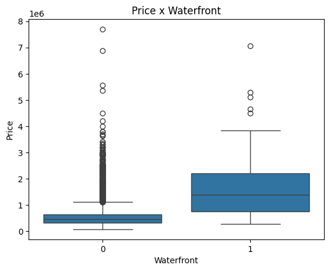

```python
sns.boxplot(x = 'waterfront', y = 'price', data = df)
plt.ylabel('Price')
plt.xlabel('Waterfront')
plt.title('Price x Waterfront')
plt.show()
```

#### Evidentemente, a área útil das casas também impactam bastante nos preços. A varíavel 'sqft_above', nos conta o quantos metros quadrados possuimos de área útil, sem contar o porão.

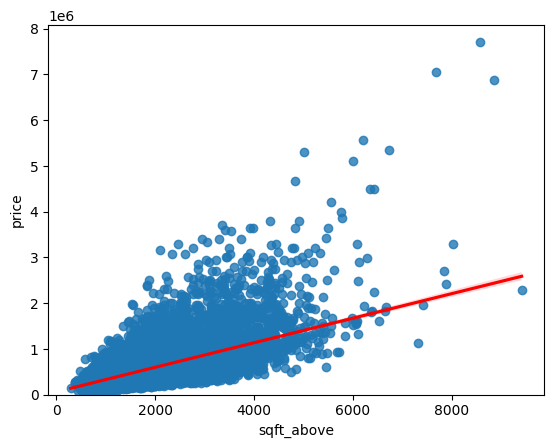

```python
colors = {'color':'red'}
sns.regplot(x = 'sqft_above', y = 'price' , data = df, line_kws = colors)
plt.ylim(0,)
plt.show()
```

## Criação de modelo para previsão de preços

#### Com base na tabela da correlação das varíaveis em relação ao preço, irei juntar as caracteristícas que mais impactam na previsão do valor final.

```python
## Modelo de Regressão Linear
lr = LinearRegression()
```

```python
features = ["floors", "waterfront","lat" ,"bedrooms" ,"sqft_basement" ,"view" ,"bathrooms","sqft_living15","sqft_above","grade","sqft_living"]
X = df[features]
Y = df['price']
```

#### Utilizando o modelo mais simples de regressão linear temos que:

```python
lr.fit(X,Y)
print(lr.score(X,Y))
```

```
0.657638245460415
```

#### O valor representado é o Rsquared ou (R^2), que trabalha em um intervalo entre 0 e 1. Demonstrando o quão bem o modelo explica/prevê a data.

# Refinando e Avaliando o Modelo Final...

#### Esta é a parte mais importante, pois demonstra o quão bem o modelo irá trabalhar no mundo real.

```python
features = ["floors", "waterfront","lat" ,"bedrooms" ,"sqft_basement" ,"view" ,"bathrooms","sqft_living15","sqft_above","grade","sqft_living"]

x_train, x_test, y_train, y_test = train_test_split(X, Y, test_size=0.15, random_state=1) ## Dividimos nossos dados em treino e teste para a IA trabalhar.


print("Número de Amostras de Teste:", x_test.shape[0])
print("Número de Amostras de Treino:",x_train.shape[0])
```

```
Número de Amostras de Teste: 3242
Número de Amostras de Treino: 18371
```

#### Agora, iremos treinar o modelo utilizando a Regressão Linear Múltipla, e por meio do método da Cross-Validation será possível checar se nosso modelo está OverFitting ou UnderFitting nossos dados. Para facilitar e padronizar o treino, foi criado um Pipeline para facilitar o processo. Irei testar polinômios de ordem 1,2,3 que são os mais comuns para estimativas de dados.

|  | Grau 1 | Grau 2 | Grau 3 |
| --- | --- | --- | --- |
| Média de Rsquared | 0.6580 | 0.7390 | 0.0430 |
| Desvio Padrão | 0.0081 | 0.0193 | 1.4428 |

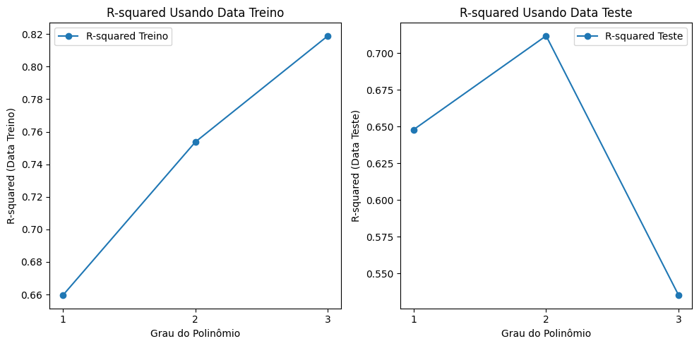

```python
# Definindo os graus dos polinômios
order = [1, 2, 3]

# Inicializando listas vazias para uso da função
Rsqu_test = []
Rsqu_train = []
Mean_List = {}
Std_List = {}

# Criando um Pipeline com PolynomialFeatures e LinearRegression
for n in order:
    Input = [('scale',StandardScaler()),('polynomial', PolynomialFeatures(degree=n,include_bias=False)),('model',LinearRegression())]
    pipeline = Pipeline(Input)

    # Ajustando o pipeline para a data de treino
    pipeline.fit(x_train[features], y_train)

    # Avaliando o modelo usando Cross_Validation
    cv_scores = cross_val_score(pipeline, x_train[features], y_train, cv=5)
    mean_r2 = np.mean(cv_scores)
    Mean_List[f'Grau {n}'] = mean_r2.round(3)
    Std_List[f'Grau {n}'] = cv_scores.std().round(4)

    # Calculando o Rsquared da data teste e treino
    Rsqu_test.append(pipeline.score(x_test[features], y_test))
    Rsqu_train.append(pipeline.score(x_train[features], y_train))


# Criando um DataFrame dos resultados para melhor visualização
nwdf = pd.DataFrame([Mean_List, Std_List])
nwdf.rename(index={0: 'Média de Rsquared', 1: 'Desvio Padrão'}, inplace=True)
display(nwdf)

# Plotando os resultados para melhor visualização
plt.figure(figsize=(10, 5))
plt.subplot(1, 2, 1)
plt.plot(order, Rsqu_train, marker='o', label='R-squared Treino')
plt.xlabel('Grau do Polinômio')
plt.xticks(np.arange(min(order),max(order)+0.1,1))
plt.ylabel('R-squared (Data Treino)')
plt.title('R-squared Usando Data Treino')
plt.legend()

plt.subplot(1, 2, 2)
plt.plot(order, Rsqu_test, marker='o', label='R-squared Teste')
plt.xlabel('Grau do Polinômio')
plt.xticks(np.arange(min(order),max(order)+0.1,1))
plt.ylabel('R-squared (Data Teste)')
plt.title('R-squared Usando Data Teste')
plt.legend()

plt.tight_layout()
plt.show()
```

#### É perceptível que o polinômio que melhor se ajusta é o de grau 2. Já que é o 'pico' do valor de Rsquared antes de decair por polinômios posteriores, o que seria um sinal de Overfitting. Além disso, esses valores são confiáveis, pois temos um R-Squared parecido para ambos os dados(treino e teste)

#### Na célula abaixo inserimos o melhor grau encontrado:

```python
n = int(input("Insira o grau do polinômio"))
Input = [('scale',StandardScaler()),('polynomial', PolynomialFeatures(degree=n,include_bias=False)),('model',LinearRegression())]
pipeline = Pipeline(Input)
# Fit the pipeline to the training data
pipeline.fit(x_train[features], y_train)
```

```
Pipeline(steps=[('scale', StandardScaler()),
                ('polynomial', PolynomialFeatures(include_bias=False)),
                ('model', LinearRegression())])
```

```python
## Treinamos para prever resultados
yhat_train = pipeline.predict(x_train[features])
yhat_test = pipeline.predict(x_test[features])
```

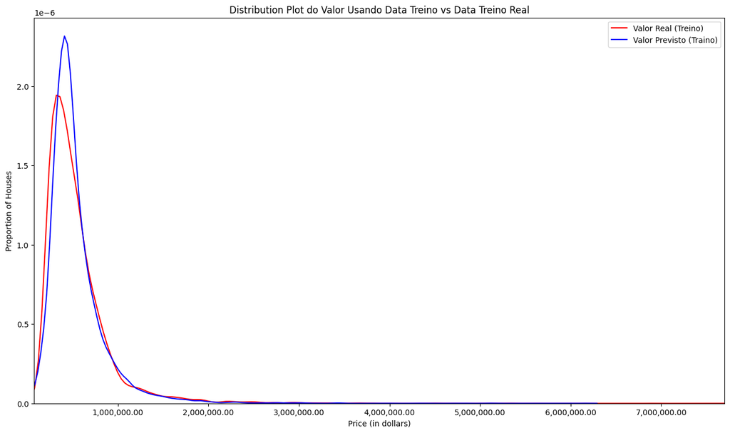

```python
Title = 'Distribution Plot do Valor Usando Data Treino vs Data Treino Real'
DistributionPlot(y_train, yhat_train, "Valor Real (Treino)", "Valor Previsto (Traino)", Title)
```

### É possível perceber pelo Distribution Plot que nosso modelo, em sua maioria, possui uma boa acurácia. Apenas deviando um pouco mais nos valores por volta de 500.000, provavelmente se houvessem mais dados essa acurácia melhoraria.

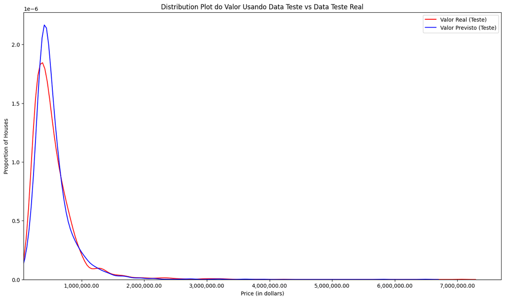

```python
Title='Distribution Plot do Valor Usando Data Teste vs Data Teste Real'
DistributionPlot(y_test, yhat_test, "Valor Real (Teste)", "Valor Previsto (Teste)", Title)
```

#### Introduzindo novos dados, o modelo também teve uma boa performance, mas novamente nos valores por volta de 500.000 se distoaram um pouco mais.

#### Utilziando a regressão de Ridge podemos achar um Hiperparâmetro Alpha que ajude nosso modelo se ajustar melhor em nossa data, ele ajuda a escalonar/regularizar nossa data, prevenindo ainda mais o OverFitting

```python
### Primeiramente, passo uma lista de parâmetros Alpha a serem testados por meio do GridSearch, que ajuda a encontrar o melhor entre eles.
parameters1= [{'alpha': [0.001, 0.1, 1, 10, 100, 1000, 10000, 100000, 100000]}]
RR = Ridge()
Grid1 = GridSearchCV(RR,parameters1,cv=5)
Grid1.fit(df[features], df['price'])
BestRR = Grid1.best_estimator_
print(BestRR)
BestRR.score(x_test[features],y_test)
```

```
Ridge(alpha=1)
```

```
0.6493341348951372
```

#### Finalizando... Eu aplico o parâmetro alfa encontrado no modelo atual.

```python
poly = PolynomialFeatures(degree= n)
RR = Ridge(alpha=BestRR.alpha)

pipeline = Pipeline([('polynomial_features', poly),('ridge_regression', RR)])
pipeline.fit(x_train, y_train)

y_hat = pipeline.predict(x_test)

r2 = r2_score(y_test, y_hat)
print(f"R-squared score: {r2:.3f}")
```

```
R-squared score: 0.700
```

### Dessa forma, ao final o modelo criado possui uma precisão de cerca de 70% na previsão de valores. Este foi um projeto um pouco mais avançado do que os anteriores, utilizando como base alguns conceitos estatistícos fundamentais. Espero que tenha gostado! Obrigado!

#### Qualquer dica, estou aberto a sugestões, obrigado!